# ANCOVA in flow (ativ. leitura) (flow (ativ. leitura))

Geiser C. Challco geiser@alumni.usp.br

- Descriptive Statistics of Initial Data
- ANCOVA and Pairwise for one factor: **grupo**
  - Without remove non-normal data
  - Computing ANCOVA and PairWise After removing non-normal data (OK)
    - Plots for ancova
    - Checking linearity assumption
    - Checking normality and homogeneity
- ANCOVA and Pairwise for two factors **grupo:Sexo**
  - Without remove non-normal data
  - Computing ANCOVA and PairWise After removing non-normal data (OK)
    - Plots for ancova
    - Checking linearity assumption
    - Checking normality and homogeneity
- ANCOVA and Pairwise for two factors **grupo:Zona**
  - Without remove non-normal data
  - Computing ANCOVA and PairWise After removing non-normal data (OK)
    - Plots for ancova
    - Checking linearity assumption
    - Checking normality and homogeneity
- ANCOVA and Pairwise for two factors **grupo:Cor.Raca**
  - Without remove non-normal data
  - Computing ANCOVA and PairWise After removing non-normal data (OK)
    - Plots for ancova
    - Checking linearity assumption
    - Checking normality and homogeneity
- Summary of Results
  - Descriptive Statistics
  - ANCOVA Table Comparison
  - PairWise Table Comparison
  - EMMS Table Comparison

**NOTE**:

- Teste ANCOVA para determinar se houve diferenças significativas no flow (ativ. leitura) (medido usando pre- e pos-testes).
- ANCOVA test to determine whether there were significant differences in flow (ativ. leitura) (measured using pre- and post-tests).

# Descriptive Statistics of Initial Data

```r
df <- get.descriptives(dat, c(dv.pre, dv.pos), c("grupo"),
                       include.global = T, symmetry.test = T, normality.test = F)
df <- plyr::rbind.fill(
  df, do.call(plyr::rbind.fill, lapply(lfatores2, FUN = function(f) {
    if (nrow(dat) > 0 && sum(!is.na(unique(dat[[f]]))) > 1)
      get.descriptives(dat, c(dv.pre,dv.pos), c("grupo", f),
                       symmetry.test = T, normality.test = F)
    }))
)
(df <- df[,c(fatores1[fatores1 %in% colnames(df)],"variable",
             colnames(df)[!colnames(df) %in% c(fatores1,"variable")])])
```

```
##           grupo Sexo   Zona Cor.Raca       variable   n  mean median   min   max    sd    se    ci   iqr
## 1      Controle <NA>   <NA>     <NA> dfs.media.read  88 3.462  3.444 2.556 4.556 0.449 0.048 0.095 0.694
## 2  Experimental <NA>   <NA>     <NA> dfs.media.read 176 3.445  3.444 1.889 4.667 0.491 0.037 0.073 0.667
## 3          <NA> <NA>   <NA>     <NA> dfs.media.read 264 3.451  3.444 1.889 4.667 0.476 0.029 0.058 0.667
## 4      Controle <NA>   <NA>     <NA> fss.media.read  88 3.415  3.444 2.000 4.778 0.549 0.058 0.116 0.778
## 5  Experimental <NA>   <NA>     <NA> fss.media.read 176 3.406  3.444 1.000 4.667 0.542 0.041 0.081 0.778
## 6          <NA> <NA>   <NA>     <NA> fss.media.read 264 3.409  3.444 1.000 4.778 0.543 0.033 0.066 0.778
## 7      Controle    F   <NA>     <NA> dfs.media.read  47 3.520  3.667 2.556 4.556 0.453 0.066 0.133 0.556
## 8      Controle    M   <NA>     <NA> dfs.media.read  41 3.396  3.333 2.556 4.222 0.440 0.069 0.139 0.667
## 9  Experimental    F   <NA>     <NA> dfs.media.read 101 3.527  3.556 1.889 4.667 0.508 0.051 0.100 0.667
## 10 Experimental    M   <NA>     <NA> dfs.media.read  75 3.335  3.333 2.250 4.333 0.447 0.052 0.103 0.611
## 11     Controle    F   <NA>     <NA> fss.media.read  47 3.527  3.556 2.333 4.778 0.567 0.083 0.167 0.556
## 12     Controle    M   <NA>     <NA> fss.media.read  41 3.286  3.222 2.000 4.556 0.503 0.079 0.159 0.667
## 13 Experimental    F   <NA>     <NA> fss.media.read 101 3.408  3.444 2.444 4.667 0.497 0.049 0.098 0.667
## 14 Experimental    M   <NA>     <NA> fss.media.read  75 3.403  3.444 1.000 4.667 0.600 0.069 0.138 0.778
```

[output cut: 67 more lines]

| grupo | Sexo | Zona | Cor.Raca | variable | n | mean | median | min | max | sd | se | ci | iqr | symmetry | skewness | kurtosis |
| --- | --- | --- | --- | --- | --- | --- | --- | --- | --- | --- | --- | --- | --- | --- | --- | --- |
| Controle |  |  |  | dfs.media.read | 88 | 3.462 | 3.444 | 2.556 | 4.556 | 0.449 | 0.048 | 0.095 | 0.694 | YES | -0.047 | -0.778 |
| Experimental |  |  |  | dfs.media.read | 176 | 3.445 | 3.444 | 1.889 | 4.667 | 0.491 | 0.037 | 0.073 | 0.667 | YES | -0.134 | 0.011 |
|  |  |  |  | dfs.media.read | 264 | 3.451 | 3.444 | 1.889 | 4.667 | 0.476 | 0.029 | 0.058 | 0.667 | YES | -0.115 | -0.151 |
| Controle |  |  |  | fss.media.read | 88 | 3.415 | 3.444 | 2.000 | 4.778 | 0.549 | 0.058 | 0.116 | 0.778 | YES | 0.068 | -0.036 |
| Experimental |  |  |  | fss.media.read | 176 | 3.406 | 3.444 | 1.000 | 4.667 | 0.542 | 0.041 | 0.081 | 0.778 | YES | -0.244 | 1.274 |
|  |  |  |  | fss.media.read | 264 | 3.409 | 3.444 | 1.000 | 4.778 | 0.543 | 0.033 | 0.066 | 0.778 | YES | -0.138 | 0.857 |
| Controle | F |  |  | dfs.media.read | 47 | 3.520 | 3.667 | 2.556 | 4.556 | 0.453 | 0.066 | 0.133 | 0.556 | YES | -0.321 | -0.537 |
| Controle | M |  |  | dfs.media.read | 41 | 3.396 | 3.333 | 2.556 | 4.222 | 0.440 | 0.069 | 0.139 | 0.667 | YES | 0.267 | -0.894 |
| Experimental | F |  |  | dfs.media.read | 101 | 3.527 | 3.556 | 1.889 | 4.667 | 0.508 | 0.051 | 0.100 | 0.667 | YES | -0.350 | 0.224 |
| Experimental | M |  |  | dfs.media.read | 75 | 3.335 | 3.333 | 2.250 | 4.333 | 0.447 | 0.052 | 0.103 | 0.611 | YES | 0.064 | -0.096 |
| Controle | F |  |  | fss.media.read | 47 | 3.527 | 3.556 | 2.333 | 4.778 | 0.567 | 0.083 | 0.167 | 0.556 | YES | -0.106 | -0.036 |
| Controle | M |  |  | fss.media.read | 41 | 3.286 | 3.222 | 2.000 | 4.556 | 0.503 | 0.079 | 0.159 | 0.667 | YES | 0.162 | 0.015 |
| Experimental | F |  |  | fss.media.read | 101 | 3.408 | 3.444 | 2.444 | 4.667 | 0.497 | 0.049 | 0.098 | 0.667 | YES | 0.328 | -0.287 |
| Experimental | M |  |  | fss.media.read | 75 | 3.403 | 3.444 | 1.000 | 4.667 | 0.600 | 0.069 | 0.138 | 0.778 | NO | -0.667 | 1.921 |
| Controle |  | Rural |  | dfs.media.read | 31 | 3.380 | 3.444 | 2.556 | 4.222 | 0.468 | 0.084 | 0.172 | 0.722 | YES | 0.042 | -1.217 |
| Controle |  | Urbana |  | dfs.media.read | 22 | 3.510 | 3.500 | 2.778 | 4.556 | 0.461 | 0.098 | 0.204 | 0.639 | YES | 0.205 | -0.787 |
| Controle |  |  |  | dfs.media.read | 35 | 3.505 | 3.444 | 2.556 | 4.222 | 0.426 | 0.072 | 0.146 | 0.500 | YES | -0.278 | -0.590 |
| Experimental |  | Rural |  | dfs.media.read | 54 | 3.405 | 3.410 | 1.889 | 4.444 | 0.503 | 0.069 | 0.137 | 0.528 | YES | -0.448 | 0.698 |
| Experimental |  | Urbana |  | dfs.media.read | 30 | 3.644 | 3.667 | 2.667 | 4.667 | 0.430 | 0.079 | 0.161 | 0.500 | YES | 0.202 | -0.108 |
| Experimental |  |  |  | dfs.media.read | 92 | 3.404 | 3.333 | 2.333 | 4.444 | 0.491 | 0.051 | 0.102 | 0.757 | YES | 0.066 | -0.658 |
| Controle |  | Rural |  | fss.media.read | 31 | 3.430 | 3.444 | 2.333 | 4.556 | 0.537 | 0.096 | 0.197 | 0.722 | YES | -0.047 | -0.495 |
| Controle |  | Urbana |  | fss.media.read | 22 | 3.415 | 3.444 | 2.556 | 4.778 | 0.485 | 0.103 | 0.215 | 0.639 | NO | 0.673 | 0.688 |
| Controle |  |  |  | fss.media.read | 35 | 3.401 | 3.444 | 2.000 | 4.667 | 0.609 | 0.103 | 0.209 | 0.778 | YES | -0.044 | -0.362 |
| Experimental |  | Rural |  | fss.media.read | 54 | 3.466 | 3.444 | 2.333 | 4.667 | 0.520 | 0.071 | 0.142 | 0.667 | YES | 0.018 | -0.266 |
| Experimental |  | Urbana |  | fss.media.read | 30 | 3.379 | 3.278 | 2.444 | 4.667 | 0.605 | 0.110 | 0.226 | 0.944 | YES | 0.377 | -0.934 |
| Experimental |  |  |  | fss.media.read | 92 | 3.380 | 3.389 | 1.000 | 4.556 | 0.536 | 0.056 | 0.111 | 0.667 | NO | -0.643 | 2.859 |
| Controle |  |  | Branca | dfs.media.read | 4 | 3.528 | 3.611 | 2.889 | 4.000 | 0.483 | 0.242 | 0.769 | 0.528 | YES | -0.311 | -1.990 |
| Controle |  |  | Parda | dfs.media.read | 32 | 3.309 | 3.389 | 2.556 | 4.222 | 0.454 | 0.080 | 0.164 | 0.694 | YES | 0.089 | -1.113 |
| Controle |  |  |  | dfs.media.read | 52 | 3.551 | 3.556 | 2.667 | 4.556 | 0.426 | 0.059 | 0.119 | 0.583 | YES | -0.026 | -0.658 |
| Experimental |  |  | Amarela | dfs.media.read | 2 | 2.889 | 2.889 | 2.444 | 3.333 | 0.629 | 0.444 | 5.647 | 0.444 | few data | 0.000 | 0.000 |
| Experimental |  |  | Branca | dfs.media.read | 17 | 3.418 | 3.333 | 2.778 | 4.222 | 0.413 | 0.100 | 0.212 | 0.444 | YES | 0.257 | -0.767 |
| Experimental |  |  | Parda | dfs.media.read | 45 | 3.514 | 3.444 | 2.333 | 4.444 | 0.447 | 0.067 | 0.134 | 0.556 | YES | 0.236 | -0.001 |
| Experimental |  |  |  | dfs.media.read | 112 | 3.432 | 3.444 | 1.889 | 4.667 | 0.514 | 0.049 | 0.096 | 0.667 | YES | -0.226 | -0.125 |
| Controle |  |  | Branca | fss.media.read | 4 | 3.806 | 3.611 | 3.333 | 4.667 | 0.604 | 0.302 | 0.962 | 0.583 | NO | 0.551 | -1.844 |
| Controle |  |  | Parda | fss.media.read | 32 | 3.375 | 3.333 | 2.333 | 4.556 | 0.549 | 0.097 | 0.198 | 0.694 | YES | 0.193 | -0.755 |
| Controle |  |  |  | fss.media.read | 52 | 3.409 | 3.444 | 2.000 | 4.778 | 0.544 | 0.075 | 0.151 | 0.778 | YES | -0.080 | 0.227 |
| Experimental |  |  | Amarela | fss.media.read | 2 | 3.278 | 3.278 | 3.222 | 3.333 | 0.079 | 0.056 | 0.706 | 0.056 | few data | 0.000 | 0.000 |
| Experimental |  |  | Branca | fss.media.read | 17 | 3.503 | 3.444 | 2.778 | 4.111 | 0.401 | 0.097 | 0.206 | 0.556 | YES | -0.188 | -1.341 |
| Experimental |  |  | Parda | fss.media.read | 45 | 3.426 | 3.444 | 2.444 | 4.667 | 0.523 | 0.078 | 0.157 | 0.667 | YES | 0.305 | -0.452 |
| Experimental |  |  |  | fss.media.read | 112 | 3.385 | 3.389 | 1.000 | 4.667 | 0.573 | 0.054 | 0.107 | 0.730 | YES | -0.370 | 1.501 |

# ANCOVA and Pairwise for one factor: **grupo**

## Without remove non-normal data

```r
pdat = remove_group_data(dat[!is.na(dat[["grupo"]]),], "fss.media.read", "grupo")

pdat.long <- rbind(pdat[,c("id","grupo")], pdat[,c("id","grupo")])
pdat.long[["time"]] <- c(rep("pre", nrow(pdat)), rep("pos", nrow(pdat)))
pdat.long[["time"]] <- factor(pdat.long[["time"]], c("pre","pos"))
pdat.long[["flow.read"]] <- c(pdat[["dfs.media.read"]], pdat[["fss.media.read"]])

aov = anova_test(pdat, fss.media.read ~ dfs.media.read + grupo)
laov[["grupo"]] <- get_anova_table(aov)
```

```r
pwc <- emmeans_test(pdat, fss.media.read ~ grupo, covariate = dfs.media.read,
                    p.adjust.method = "bonferroni")
```

```r
pwc.long <- emmeans_test(dplyr::group_by_at(pdat.long, "grupo"),
                          flow.read ~ time,
                          p.adjust.method = "bonferroni")
lpwc[["grupo"]] <- plyr::rbind.fill(pwc, pwc.long)
```

```r
ds <- get.descriptives(pdat, "fss.media.read", "grupo", covar = "dfs.media.read")
ds <- merge(ds[ds$variable != "dfs.media.read",],
            ds[ds$variable == "dfs.media.read", !colnames(ds) %in% c("variable")],
            by = "grupo", all.x = T, suffixes = c("", ".dfs.media.read"))
ds <- merge(get_emmeans(pwc), ds, by = "grupo", suffixes = c(".emms", ""))
ds <- ds[,c("grupo","n","mean.dfs.media.read","se.dfs.media.read","mean","se","emmean","se.emms")]

colnames(ds) <- c("grupo", "N", paste0(c("M","SE")," (pre)"),
                  paste0(c("M","SE"), " (unadj)"), paste0(c("M", "SE"), " (adj)"))

lemms[["grupo"]] <- ds
```

## Computing ANCOVA and PairWise After removing non-normal data (OK)

```r
wdat = pdat

res = residuals(lm(fss.media.read ~ dfs.media.read + grupo, data = wdat))
non.normal = getNonNormal(res, wdat$id, plimit = 0.05)

wdat = wdat[!wdat$id %in% non.normal,]

wdat.long <- rbind(wdat[,c("id","grupo")], wdat[,c("id","grupo")])
wdat.long[["time"]] <- c(rep("pre", nrow(wdat)), rep("pos", nrow(wdat)))
wdat.long[["time"]] <- factor(wdat.long[["time"]], c("pre","pos"))
wdat.long[["flow.read"]] <- c(wdat[["dfs.media.read"]], wdat[["fss.media.read"]])

ldat[["grupo"]] = wdat

(non.normal)
```

```
## [1] "P2052"
```

```r
aov = anova_test(wdat, fss.media.read ~ dfs.media.read + grupo)
laov[["grupo"]] <- merge(get_anova_table(aov), laov[["grupo"]], by="Effect", suffixes = c("","'"))

(df = get_anova_table(aov))
```

```
## ANOVA Table (type II tests)
##
##           Effect DFn DFd      F        p p<.05      ges
## 1 dfs.media.read   1 260 28.908 1.69e-07     * 1.00e-01
## 2          grupo   1 260  0.024 8.77e-01       9.22e-05
```

| Effect | DFn | DFd | F | p | p<.05 | ges |
| --- | --- | --- | --- | --- | --- | --- |
| dfs.media.read | 1 | 260 | 28.908 | 0.000 | * | 0.1 |
| grupo | 1 | 260 | 0.024 | 0.877 |  | 0.0 |

| term | .y. | group1 | group2 | df | statistic | p | p.adj | p.adj.signif |
| --- | --- | --- | --- | --- | --- | --- | --- | --- |
| dfs.media.read*grupo | fss.media.read | Controle | Experimental | 260 | -0.155 | 0.877 | 0.877 | ns |

```r
pwc.long <- emmeans_test(dplyr::group_by_at(wdat.long, "grupo"),
                         flow.read ~ time,
                         p.adjust.method = "bonferroni")
lpwc[["grupo"]] <- merge(plyr::rbind.fill(pwc, pwc.long), lpwc[["grupo"]], by=c("grupo","term",".y.","group1","group2"), suffixes = c("","'"))
```

| grupo | term | .y. | group1 | group2 | df | statistic | p | p.adj | p.adj.signif |
| --- | --- | --- | --- | --- | --- | --- | --- | --- | --- |
| Controle | time | flow.read | pre | pos | 522 | 0.629 | 0.530 | 0.530 | ns |
| Experimental | time | flow.read | pre | pos | 522 | 0.524 | 0.601 | 0.601 | ns |

```r
ds <- get.descriptives(wdat, "fss.media.read", "grupo", covar = "dfs.media.read")
ds <- merge(ds[ds$variable != "dfs.media.read",],
            ds[ds$variable == "dfs.media.read", !colnames(ds) %in% c("variable")],
            by = "grupo", all.x = T, suffixes = c("", ".dfs.media.read"))
ds <- merge(get_emmeans(pwc), ds, by = "grupo", suffixes = c(".emms", ""))
ds <- ds[,c("grupo","n","mean.dfs.media.read","se.dfs.media.read","mean","se","emmean","se.emms")]

colnames(ds) <- c("grupo", "N", paste0(c("M","SE")," (pre)"),
                  paste0(c("M","SE"), " (unadj)"), paste0(c("M", "SE"), " (adj)"))

lemms[["grupo"]] <- merge(ds, lemms[["grupo"]], by=c("grupo"), suffixes = c("","'"))
```

| grupo | N | M (pre) | SE (pre) | M (unadj) | SE (unadj) | M (adj) | SE (adj) |
| --- | --- | --- | --- | --- | --- | --- | --- |
| Controle | 88 | 3.462 | 0.048 | 3.415 | 0.058 | 3.411 | 0.053 |
| Experimental | 175 | 3.448 | 0.037 | 3.420 | 0.039 | 3.421 | 0.038 |

### Plots for ancova

```r
plots <- oneWayAncovaPlots(
  wdat, "fss.media.read", "grupo", aov, list("grupo"=pwc), addParam = c("mean_se"),
  font.label.size=10, step.increase=0.05, p.label="p.adj",
  subtitle = which(aov$Effect == "grupo"))
```

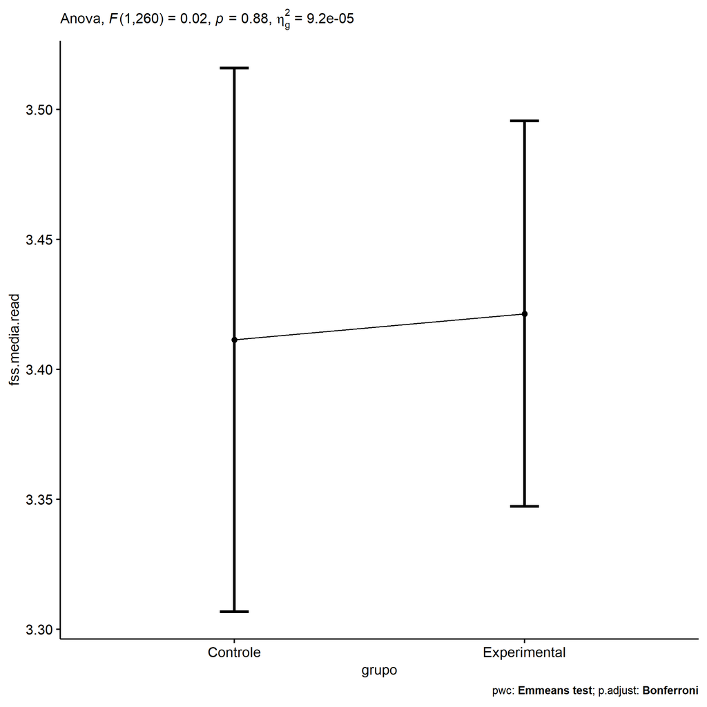

```r
if (!is.null(nrow(plots[["grupo"]]$data)))
  plots[["grupo"]] + ggplot2::scale_color_manual(values = color[["grupo"]])
```

```r
plots <- oneWayAncovaBoxPlots(
  wdat, "fss.media.read", "grupo", aov, pwc, covar = "dfs.media.read",
  theme = "classic", color = color[["grupo"]],
  subtitle = which(aov$Effect == "grupo"))
```

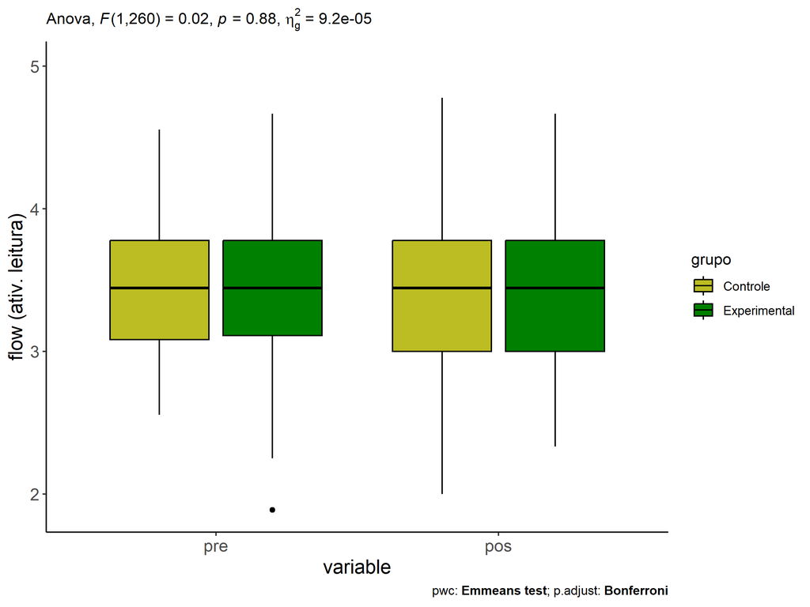

```r
if (length(unique(wdat[["grupo"]])) > 1)
  plots[["grupo"]] + ggplot2::ylab("flow (ativ. leitura)") + ggplot2::scale_x_discrete(labels=c('pre', 'pos'))
```

```r
if (length(unique(wdat.long[["grupo"]])) > 1)
  plots <- oneWayAncovaBoxPlots(
    wdat.long, "flow.read", "grupo", aov, pwc.long, pre.post = "time",
    theme = "classic", color = color$prepost)
```

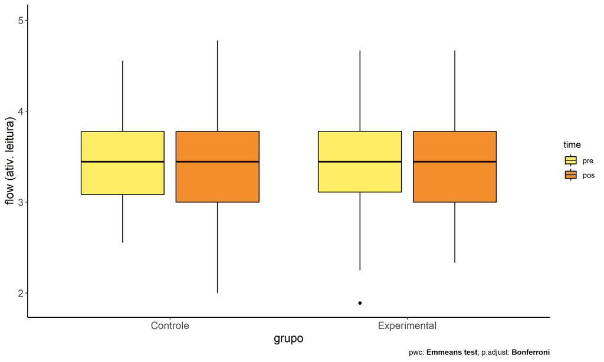

```r
if (length(unique(wdat.long[["grupo"]])) > 1)
  plots[["grupo"]] + ggplot2::ylab("flow (ativ. leitura)")
```

### Checking linearity assumption

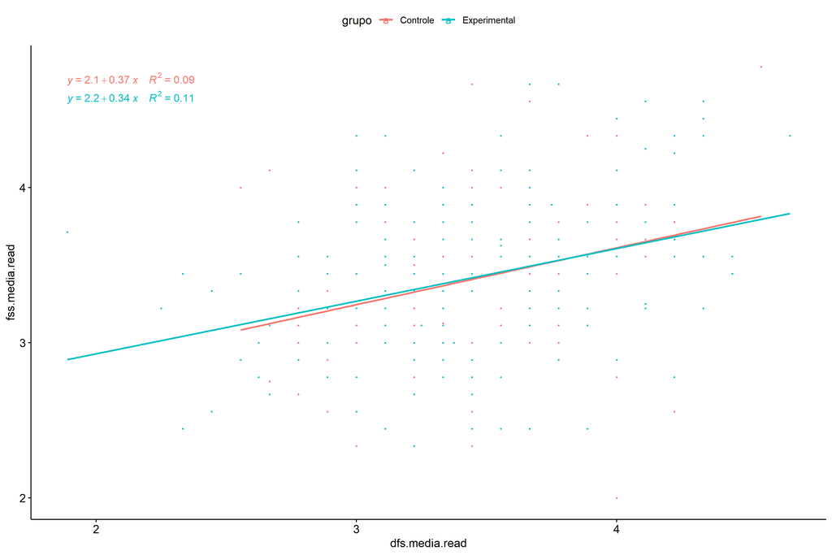

```r
ggscatter(wdat, x = "dfs.media.read", y = "fss.media.read", size = 0.5,
          color = "grupo", add = "reg.line")+
  stat_regline_equation(
    aes(label =  paste(..eq.label.., ..rr.label.., sep = "~~~~"), color = grupo)
  )
```

### Checking normality and homogeneity

```r
res <- augment(lm(fss.media.read ~ dfs.media.read + grupo, data = wdat))
```

```r
shapiro_test(res$.resid)
```

```
## # A tibble: 1 × 3
##   variable   statistic p.value
##   <chr>          <dbl>   <dbl>
## 1 res$.resid     0.993   0.250
```

```r
levene_test(res, .resid ~ grupo)
```

```
## # A tibble: 1 × 4
##     df1   df2 statistic     p
##   <int> <int>     <dbl> <dbl>
## 1     1   261   0.00233 0.962
```

# ANCOVA and Pairwise for two factors **grupo:Sexo**

## Without remove non-normal data

```r
pdat = remove_group_data(dat[!is.na(dat[["grupo"]]) & !is.na(dat[["Sexo"]]),], "fss.media.read", c("grupo","Sexo"))

pdat.long <- rbind(pdat[,c("id","grupo","Sexo")], pdat[,c("id","grupo","Sexo")])
pdat.long[["time"]] <- c(rep("pre", nrow(pdat)), rep("pos", nrow(pdat)))
pdat.long[["time"]] <- factor(pdat.long[["time"]], c("pre","pos"))
pdat.long[["flow.read"]] <- c(pdat[["dfs.media.read"]], pdat[["fss.media.read"]])

aov = anova_test(pdat, fss.media.read ~ dfs.media.read + grupo*Sexo)
laov[["grupo:Sexo"]] <- get_anova_table(aov)
```

```r
pwcs <- list()
pwcs[["Sexo"]] <- emmeans_test(
  group_by(pdat, grupo), fss.media.read ~ Sexo,
  covariate = dfs.media.read, p.adjust.method = "bonferroni")
pwcs[["grupo"]] <- emmeans_test(
  group_by(pdat, Sexo), fss.media.read ~ grupo,
  covariate = dfs.media.read, p.adjust.method = "bonferroni")

pwc <- plyr::rbind.fill(pwcs[["grupo"]], pwcs[["Sexo"]])
pwc <- pwc[,c("grupo","Sexo", colnames(pwc)[!colnames(pwc) %in% c("grupo","Sexo")])]
```

```r
pwc.long <- emmeans_test(dplyr::group_by_at(pdat.long, c("grupo","Sexo")),
                         flow.read ~ time,
                         p.adjust.method = "bonferroni")
lpwc[["grupo:Sexo"]] <- plyr::rbind.fill(pwc, pwc.long)
```

```r
ds <- get.descriptives(pdat, "fss.media.read", c("grupo","Sexo"), covar = "dfs.media.read")
ds <- merge(ds[ds$variable != "dfs.media.read",],
            ds[ds$variable == "dfs.media.read", !colnames(ds) %in% c("variable")],
            by = c("grupo","Sexo"), all.x = T, suffixes = c("", ".dfs.media.read"))
ds <- merge(get_emmeans(pwcs[["grupo"]]), ds, by = c("grupo","Sexo"), suffixes = c(".emms", ""))
ds <- ds[,c("grupo","Sexo","n","mean.dfs.media.read","se.dfs.media.read","mean","se","emmean","se.emms")]

colnames(ds) <- c("grupo","Sexo", "N", paste0(c("M","SE")," (pre)"),
                  paste0(c("M","SE"), " (unadj)"), paste0(c("M", "SE"), " (adj)"))

lemms[["grupo:Sexo"]] <- ds
```

## Computing ANCOVA and PairWise After removing non-normal data (OK)

```r
wdat = pdat

res = residuals(lm(fss.media.read ~ dfs.media.read + grupo*Sexo, data = wdat))
non.normal = getNonNormal(res, wdat$id, plimit = 0.05)

wdat = wdat[!wdat$id %in% non.normal,]

wdat.long <- rbind(wdat[,c("id","grupo","Sexo")], wdat[,c("id","grupo","Sexo")])
wdat.long[["time"]] <- c(rep("pre", nrow(wdat)), rep("pos", nrow(wdat)))
wdat.long[["time"]] <- factor(wdat.long[["time"]], c("pre","pos"))
wdat.long[["flow.read"]] <- c(wdat[["dfs.media.read"]], wdat[["fss.media.read"]])


ldat[["grupo:Sexo"]] = wdat

(non.normal)
```

```
## [1] "P2052"
```

```r
aov = anova_test(wdat, fss.media.read ~ dfs.media.read + grupo*Sexo)
laov[["grupo:Sexo"]] <- merge(get_anova_table(aov), laov[["grupo:Sexo"]], by="Effect", suffixes = c("","'"))

(df = get_anova_table(aov))
```

```
## ANOVA Table (type II tests)
##
##           Effect DFn DFd      F        p p<.05      ges
## 1 dfs.media.read   1 258 28.917 1.69e-07     * 1.01e-01
## 2          grupo   1 258  0.023 8.80e-01       8.90e-05
## 3           Sexo   1 258  0.008 9.27e-01       3.28e-05
## 4     grupo:Sexo   1 258  4.954 2.70e-02     * 1.90e-02
```

| Effect | DFn | DFd | F | p | p<.05 | ges |
| --- | --- | --- | --- | --- | --- | --- |
| dfs.media.read | 1 | 258 | 28.917 | 0.000 | * | 0.101 |
| grupo | 1 | 258 | 0.023 | 0.880 |  | 0.000 |
| Sexo | 1 | 258 | 0.008 | 0.927 |  | 0.000 |
| grupo:Sexo | 1 | 258 | 4.954 | 0.027 | * | 0.019 |

```r
pwcs <- list()
pwcs[["Sexo"]] <- emmeans_test(
  group_by(wdat, grupo), fss.media.read ~ Sexo,
  covariate = dfs.media.read, p.adjust.method = "bonferroni")
pwcs[["grupo"]] <- emmeans_test(
  group_by(wdat, Sexo), fss.media.read ~ grupo,
  covariate = dfs.media.read, p.adjust.method = "bonferroni")

pwc <- plyr::rbind.fill(pwcs[["grupo"]], pwcs[["Sexo"]])
pwc <- pwc[,c("grupo","Sexo", colnames(pwc)[!colnames(pwc) %in% c("grupo","Sexo")])]
```

| grupo | Sexo | term | .y. | group1 | group2 | df | statistic | p | p.adj | p.adj.signif |
| --- | --- | --- | --- | --- | --- | --- | --- | --- | --- | --- |
|  | F | dfs.media.read*grupo | fss.media.read | Controle | Experimental | 258 | 1.383 | 0.168 | 0.168 | ns |
|  | M | dfs.media.read*grupo | fss.media.read | Controle | Experimental | 258 | -1.751 | 0.081 | 0.081 | ns |
| Controle |  | dfs.media.read*Sexo | fss.media.read | F | M | 258 | 1.852 | 0.065 | 0.065 | ns |
| Experimental |  | dfs.media.read*Sexo | fss.media.read | F | M | 258 | -1.215 | 0.226 | 0.226 | ns |

```r
pwc.long <- emmeans_test(dplyr::group_by_at(wdat.long, c("grupo","Sexo")),
                         flow.read ~ time,
                         p.adjust.method = "bonferroni")
lpwc[["grupo:Sexo"]] <- merge(plyr::rbind.fill(pwc, pwc.long), lpwc[["grupo:Sexo"]], by=c("grupo","Sexo","term",".y.","group1","group2"), suffixes = c("","'"))
```

| grupo | Sexo | term | .y. | group1 | group2 | df | statistic | p | p.adj | p.adj.signif |
| --- | --- | --- | --- | --- | --- | --- | --- | --- | --- | --- |
| Controle | F | time | flow.read | pre | pos | 518 | -0.063 | 0.949 | 0.949 | ns |
| Controle | M | time | flow.read | pre | pos | 518 | 0.996 | 0.319 | 0.319 | ns |
| Experimental | F | time | flow.read | pre | pos | 518 | 1.703 | 0.089 | 0.089 | ns |
| Experimental | M | time | flow.read | pre | pos | 518 | -1.178 | 0.239 | 0.239 | ns |

```r
ds <- get.descriptives(wdat, "fss.media.read", c("grupo","Sexo"), covar = "dfs.media.read")
ds <- merge(ds[ds$variable != "dfs.media.read",],
            ds[ds$variable == "dfs.media.read", !colnames(ds) %in% c("variable")],
            by = c("grupo","Sexo"), all.x = T, suffixes = c("", ".dfs.media.read"))
ds <- merge(get_emmeans(pwcs[["grupo"]]), ds, by = c("grupo","Sexo"), suffixes = c(".emms", ""))
ds <- ds[,c("grupo","Sexo","n","mean.dfs.media.read","se.dfs.media.read","mean","se","emmean","se.emms")]

colnames(ds) <- c("grupo","Sexo", "N", paste0(c("M","SE")," (pre)"),
                  paste0(c("M","SE"), " (unadj)"), paste0(c("M", "SE"), " (adj)"))

lemms[["grupo:Sexo"]] <- merge(ds, lemms[["grupo:Sexo"]], by=c("grupo","Sexo"), suffixes = c("","'"))
```

| grupo | Sexo | N | M (pre) | SE (pre) | M (unadj) | SE (unadj) | M (adj) | SE (adj) |
| --- | --- | --- | --- | --- | --- | --- | --- | --- |
| Controle | F | 47 | 3.520 | 0.066 | 3.527 | 0.083 | 3.503 | 0.072 |
| Controle | M | 41 | 3.396 | 0.069 | 3.286 | 0.079 | 3.306 | 0.077 |
| Experimental | F | 101 | 3.527 | 0.051 | 3.408 | 0.049 | 3.382 | 0.050 |
| Experimental | M | 74 | 3.339 | 0.052 | 3.435 | 0.062 | 3.475 | 0.058 |

### Plots for ancova

```r
plots <- twoWayAncovaPlots(
  wdat, "fss.media.read", c("grupo","Sexo"), aov, pwcs, addParam = c("mean_se"),
  font.label.size=10, step.increase=0.05, p.label="p.adj",
  subtitle = which(aov$Effect == "grupo:Sexo"))
```

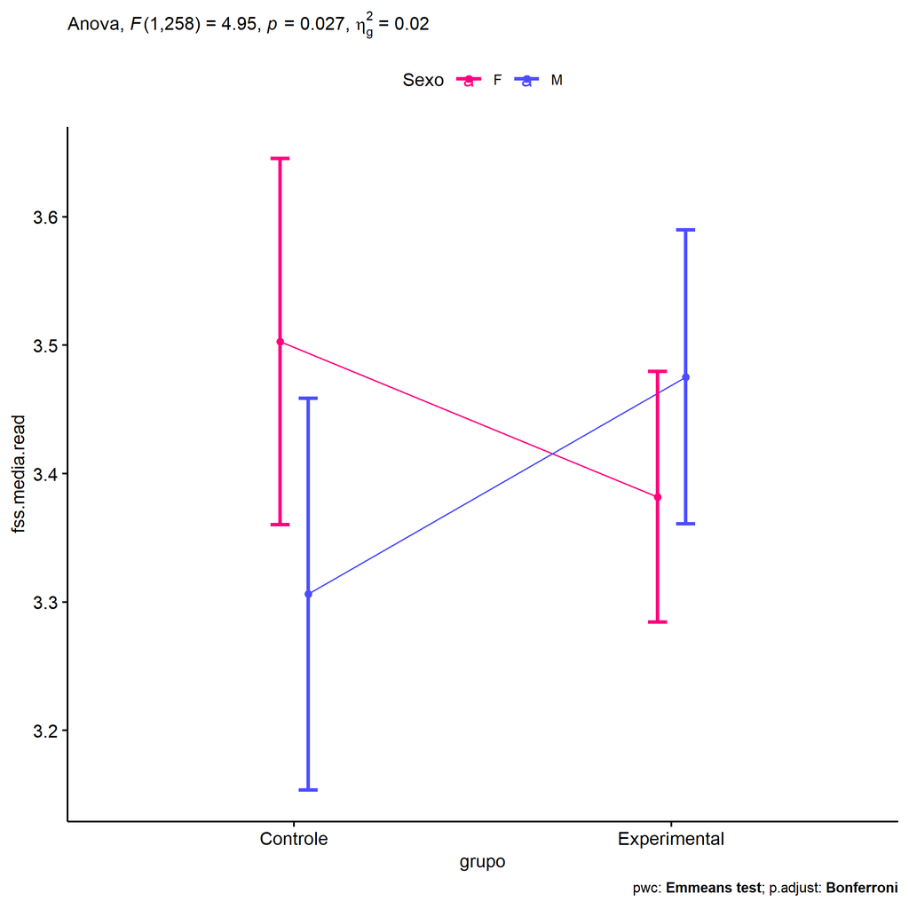

```r
if (!is.null(plots[["grupo"]]))
  plots[["grupo"]] + ggplot2::scale_color_manual(values = color[["Sexo"]])
```

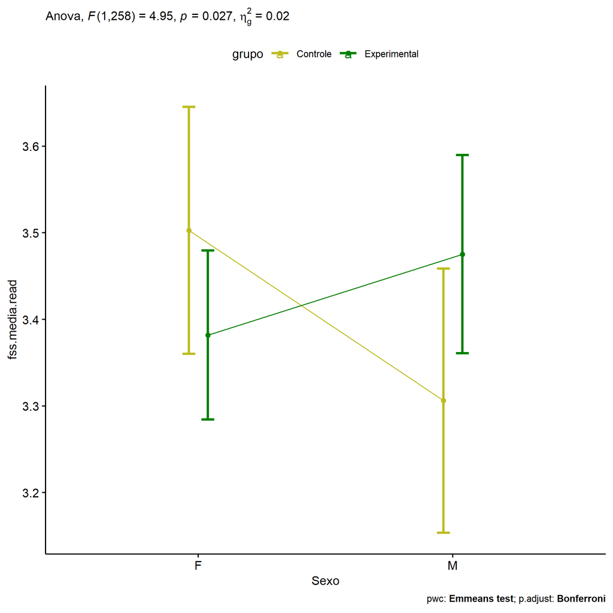

```r
if (!is.null(plots[["Sexo"]]))
  plots[["Sexo"]] + ggplot2::scale_color_manual(values = color[["grupo"]])
```

```r
plots <- twoWayAncovaBoxPlots(
  wdat, "fss.media.read", c("grupo","Sexo"), aov, pwcs, covar = "dfs.media.read",
  theme = "classic", color = color[["grupo:Sexo"]],
  subtitle = which(aov$Effect == "grupo:Sexo"))
```

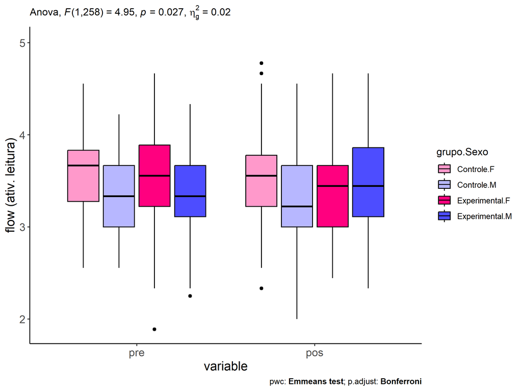

```r
plots[["grupo:Sexo"]] + ggplot2::ylab("flow (ativ. leitura)") + ggplot2::scale_x_discrete(labels=c('pre', 'pos'))
```

```r
plots <- twoWayAncovaBoxPlots(
  wdat.long, "flow.read", c("grupo","Sexo"), aov, pwc.long, pre.post = "time",
  theme = "classic", color = color$prepost)
```

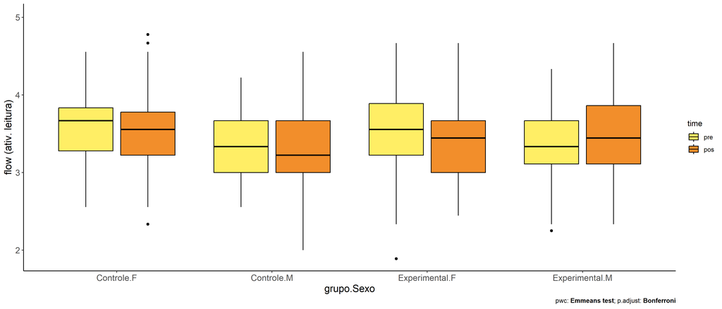

```r
plots[["grupo:Sexo"]] + ggplot2::ylab("flow (ativ. leitura)")
```

### Checking linearity assumption

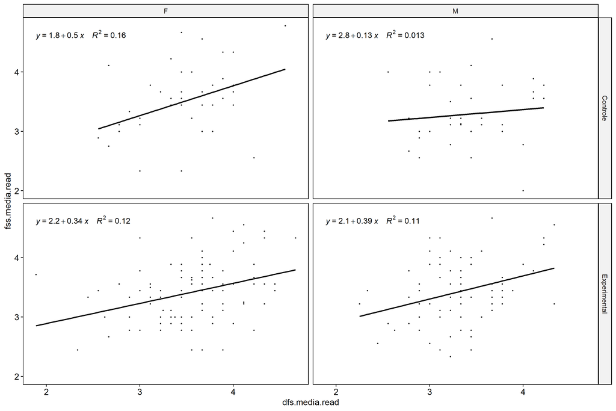

```r
ggscatter(wdat, x = "dfs.media.read", y = "fss.media.read", size = 0.5,
          facet.by = c("grupo","Sexo"), add = "reg.line")+
  stat_regline_equation(
    aes(label =  paste(..eq.label.., ..rr.label.., sep = "~~~~"))
  )
```

### Checking normality and homogeneity

```r
res <- augment(lm(fss.media.read ~ dfs.media.read + grupo*Sexo, data = wdat))
```

```r
shapiro_test(res$.resid)
```

```
## # A tibble: 1 × 3
##   variable   statistic p.value
##   <chr>          <dbl>   <dbl>
## 1 res$.resid     0.992   0.156
```

```r
levene_test(res, .resid ~ grupo*Sexo)
```

```
## # A tibble: 1 × 4
##     df1   df2 statistic     p
##   <int> <int>     <dbl> <dbl>
## 1     3   259     0.323 0.809
```

# ANCOVA and Pairwise for two factors **grupo:Zona**

## Without remove non-normal data

```r
pdat = remove_group_data(dat[!is.na(dat[["grupo"]]) & !is.na(dat[["Zona"]]),], "fss.media.read", c("grupo","Zona"))

pdat.long <- rbind(pdat[,c("id","grupo","Zona")], pdat[,c("id","grupo","Zona")])
pdat.long[["time"]] <- c(rep("pre", nrow(pdat)), rep("pos", nrow(pdat)))
pdat.long[["time"]] <- factor(pdat.long[["time"]], c("pre","pos"))
pdat.long[["flow.read"]] <- c(pdat[["dfs.media.read"]], pdat[["fss.media.read"]])

aov = anova_test(pdat, fss.media.read ~ dfs.media.read + grupo*Zona)
laov[["grupo:Zona"]] <- get_anova_table(aov)
```

```r
pwcs <- list()
pwcs[["Zona"]] <- emmeans_test(
  group_by(pdat, grupo), fss.media.read ~ Zona,
  covariate = dfs.media.read, p.adjust.method = "bonferroni")
pwcs[["grupo"]] <- emmeans_test(
  group_by(pdat, Zona), fss.media.read ~ grupo,
  covariate = dfs.media.read, p.adjust.method = "bonferroni")

pwc <- plyr::rbind.fill(pwcs[["grupo"]], pwcs[["Zona"]])
pwc <- pwc[,c("grupo","Zona", colnames(pwc)[!colnames(pwc) %in% c("grupo","Zona")])]
```

```r
pwc.long <- emmeans_test(dplyr::group_by_at(pdat.long, c("grupo","Zona")),
                         flow.read ~ time,
                         p.adjust.method = "bonferroni")
lpwc[["grupo:Zona"]] <- plyr::rbind.fill(pwc, pwc.long)
```

```r
ds <- get.descriptives(pdat, "fss.media.read", c("grupo","Zona"), covar = "dfs.media.read")
ds <- merge(ds[ds$variable != "dfs.media.read",],
            ds[ds$variable == "dfs.media.read", !colnames(ds) %in% c("variable")],
            by = c("grupo","Zona"), all.x = T, suffixes = c("", ".dfs.media.read"))
ds <- merge(get_emmeans(pwcs[["grupo"]]), ds, by = c("grupo","Zona"), suffixes = c(".emms", ""))
ds <- ds[,c("grupo","Zona","n","mean.dfs.media.read","se.dfs.media.read","mean","se","emmean","se.emms")]

colnames(ds) <- c("grupo","Zona", "N", paste0(c("M","SE")," (pre)"),
                  paste0(c("M","SE"), " (unadj)"), paste0(c("M", "SE"), " (adj)"))

lemms[["grupo:Zona"]] <- ds
```

## Computing ANCOVA and PairWise After removing non-normal data (OK)

```r
wdat = pdat

res = residuals(lm(fss.media.read ~ dfs.media.read + grupo*Zona, data = wdat))
non.normal = getNonNormal(res, wdat$id, plimit = 0.05)

wdat = wdat[!wdat$id %in% non.normal,]

wdat.long <- rbind(wdat[,c("id","grupo","Zona")], wdat[,c("id","grupo","Zona")])
wdat.long[["time"]] <- c(rep("pre", nrow(wdat)), rep("pos", nrow(wdat)))
wdat.long[["time"]] <- factor(wdat.long[["time"]], c("pre","pos"))
wdat.long[["flow.read"]] <- c(wdat[["dfs.media.read"]], wdat[["fss.media.read"]])


ldat[["grupo:Zona"]] = wdat

(non.normal)
```

[output not shown]

```r
aov = anova_test(wdat, fss.media.read ~ dfs.media.read + grupo*Zona)
laov[["grupo:Zona"]] <- merge(get_anova_table(aov), laov[["grupo:Zona"]], by="Effect", suffixes = c("","'"))

(df = get_anova_table(aov))
```

```
## ANOVA Table (type II tests)
##
##           Effect DFn DFd      F        p p<.05      ges
## 1 dfs.media.read   1 132 21.034 1.04e-05     * 0.137000
## 2          grupo   1 132  0.056 8.13e-01       0.000425
## 3           Zona   1 132  2.408 1.23e-01       0.018000
## 4     grupo:Zona   1 132  0.423 5.17e-01       0.003000
```

| Effect | DFn | DFd | F | p | p<.05 | ges |
| --- | --- | --- | --- | --- | --- | --- |
| dfs.media.read | 1 | 132 | 21.034 | 0.000 | * | 0.137 |
| grupo | 1 | 132 | 0.056 | 0.813 |  | 0.000 |
| Zona | 1 | 132 | 2.408 | 0.123 |  | 0.018 |
| grupo:Zona | 1 | 132 | 0.423 | 0.517 |  | 0.003 |

```r
pwcs <- list()
pwcs[["Zona"]] <- emmeans_test(
  group_by(wdat, grupo), fss.media.read ~ Zona,
  covariate = dfs.media.read, p.adjust.method = "bonferroni")
pwcs[["grupo"]] <- emmeans_test(
  group_by(wdat, Zona), fss.media.read ~ grupo,
  covariate = dfs.media.read, p.adjust.method = "bonferroni")

pwc <- plyr::rbind.fill(pwcs[["grupo"]], pwcs[["Zona"]])
pwc <- pwc[,c("grupo","Zona", colnames(pwc)[!colnames(pwc) %in% c("grupo","Zona")])]
```

| grupo | Zona | term | .y. | group1 | group2 | df | statistic | p | p.adj | p.adj.signif |
| --- | --- | --- | --- | --- | --- | --- | --- | --- | --- | --- |
|  | Rural | dfs.media.read*grupo | fss.media.read | Controle | Experimental | 132 | -0.221 | 0.826 | 0.826 | ns |
|  | Urbana | dfs.media.read*grupo | fss.media.read | Controle | Experimental | 132 | 0.656 | 0.513 | 0.513 | ns |
| Controle |  | dfs.media.read*Zona | fss.media.read | Rural | Urbana | 132 | 0.500 | 0.618 | 0.618 | ns |
| Experimental |  | dfs.media.read*Zona | fss.media.read | Rural | Urbana | 132 | 1.614 | 0.109 | 0.109 | ns |

```r
pwc.long <- emmeans_test(dplyr::group_by_at(wdat.long, c("grupo","Zona")),
                         flow.read ~ time,
                         p.adjust.method = "bonferroni")
lpwc[["grupo:Zona"]] <- merge(plyr::rbind.fill(pwc, pwc.long), lpwc[["grupo:Zona"]], by=c("grupo","Zona","term",".y.","group1","group2"), suffixes = c("","'"))
```

| grupo | Zona | term | .y. | group1 | group2 | df | statistic | p | p.adj | p.adj.signif |
| --- | --- | --- | --- | --- | --- | --- | --- | --- | --- | --- |
| Controle | Rural | time | flow.read | pre | pos | 266 | -0.390 | 0.697 | 0.697 | ns |
| Controle | Urbana | time | flow.read | pre | pos | 266 | 0.624 | 0.533 | 0.533 | ns |
| Experimental | Rural | time | flow.read | pre | pos | 266 | -0.621 | 0.535 | 0.535 | ns |
| Experimental | Urbana | time | flow.read | pre | pos | 266 | 2.031 | 0.043 | 0.043 | * |

```r
ds <- get.descriptives(wdat, "fss.media.read", c("grupo","Zona"), covar = "dfs.media.read")
ds <- merge(ds[ds$variable != "dfs.media.read",],
            ds[ds$variable == "dfs.media.read", !colnames(ds) %in% c("variable")],
            by = c("grupo","Zona"), all.x = T, suffixes = c("", ".dfs.media.read"))
ds <- merge(get_emmeans(pwcs[["grupo"]]), ds, by = c("grupo","Zona"), suffixes = c(".emms", ""))
ds <- ds[,c("grupo","Zona","n","mean.dfs.media.read","se.dfs.media.read","mean","se","emmean","se.emms")]

colnames(ds) <- c("grupo","Zona", "N", paste0(c("M","SE")," (pre)"),
                  paste0(c("M","SE"), " (unadj)"), paste0(c("M", "SE"), " (adj)"))

lemms[["grupo:Zona"]] <- merge(ds, lemms[["grupo:Zona"]], by=c("grupo","Zona"), suffixes = c("","'"))
```

| grupo | Zona | N | M (pre) | SE (pre) | M (unadj) | SE (unadj) | M (adj) | SE (adj) |
| --- | --- | --- | --- | --- | --- | --- | --- | --- |
| Controle | Rural | 31 | 3.380 | 0.084 | 3.430 | 0.096 | 3.467 | 0.090 |
| Controle | Urbana | 22 | 3.510 | 0.098 | 3.415 | 0.103 | 3.397 | 0.107 |
| Experimental | Rural | 54 | 3.405 | 0.069 | 3.466 | 0.071 | 3.492 | 0.068 |
| Experimental | Urbana | 30 | 3.644 | 0.079 | 3.379 | 0.110 | 3.305 | 0.093 |

### Plots for ancova

```r
plots <- twoWayAncovaPlots(
  wdat, "fss.media.read", c("grupo","Zona"), aov, pwcs, addParam = c("mean_se"),
  font.label.size=10, step.increase=0.05, p.label="p.adj",
  subtitle = which(aov$Effect == "grupo:Zona"))
```

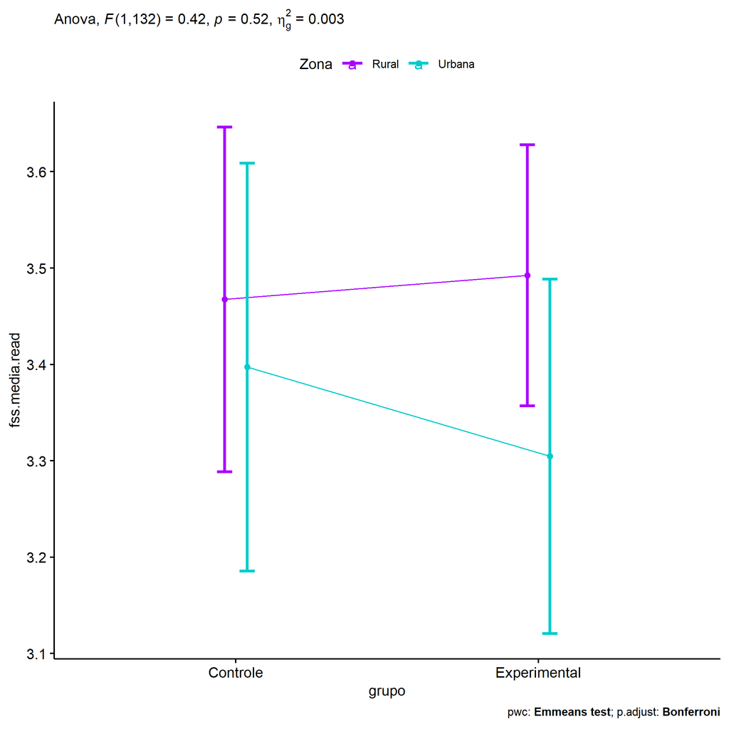

```r
if (!is.null(plots[["grupo"]]))
  plots[["grupo"]] + ggplot2::scale_color_manual(values = color[["Zona"]])
```

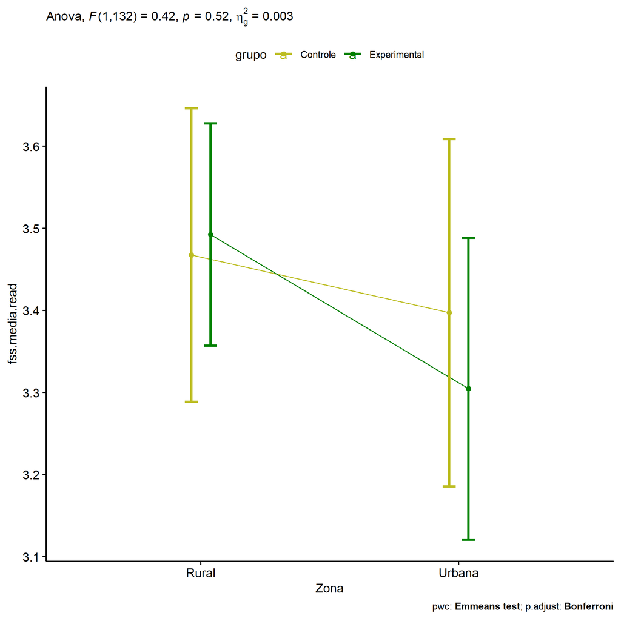

```r
if (!is.null(plots[["Zona"]]))
  plots[["Zona"]] + ggplot2::scale_color_manual(values = color[["grupo"]])
```

```r
plots <- twoWayAncovaBoxPlots(
  wdat, "fss.media.read", c("grupo","Zona"), aov, pwcs, covar = "dfs.media.read",
  theme = "classic", color = color[["grupo:Zona"]],
  subtitle = which(aov$Effect == "grupo:Zona"))
```

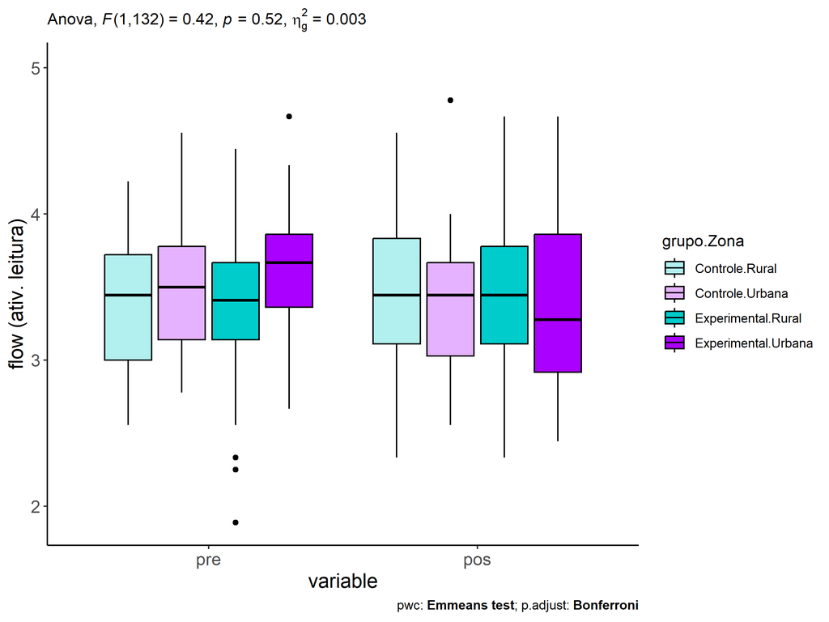

```r
plots[["grupo:Zona"]] + ggplot2::ylab("flow (ativ. leitura)") + ggplot2::scale_x_discrete(labels=c('pre', 'pos'))
```

```r
plots <- twoWayAncovaBoxPlots(
  wdat.long, "flow.read", c("grupo","Zona"), aov, pwc.long, pre.post = "time",
  theme = "classic", color = color$prepost)
```

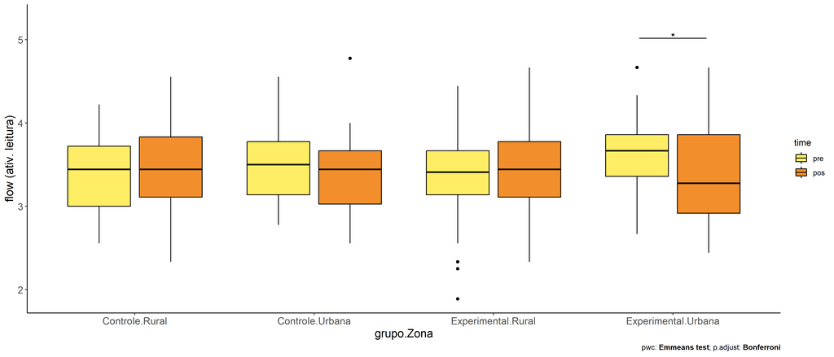

```r
plots[["grupo:Zona"]] + ggplot2::ylab("flow (ativ. leitura)")
```

### Checking linearity assumption

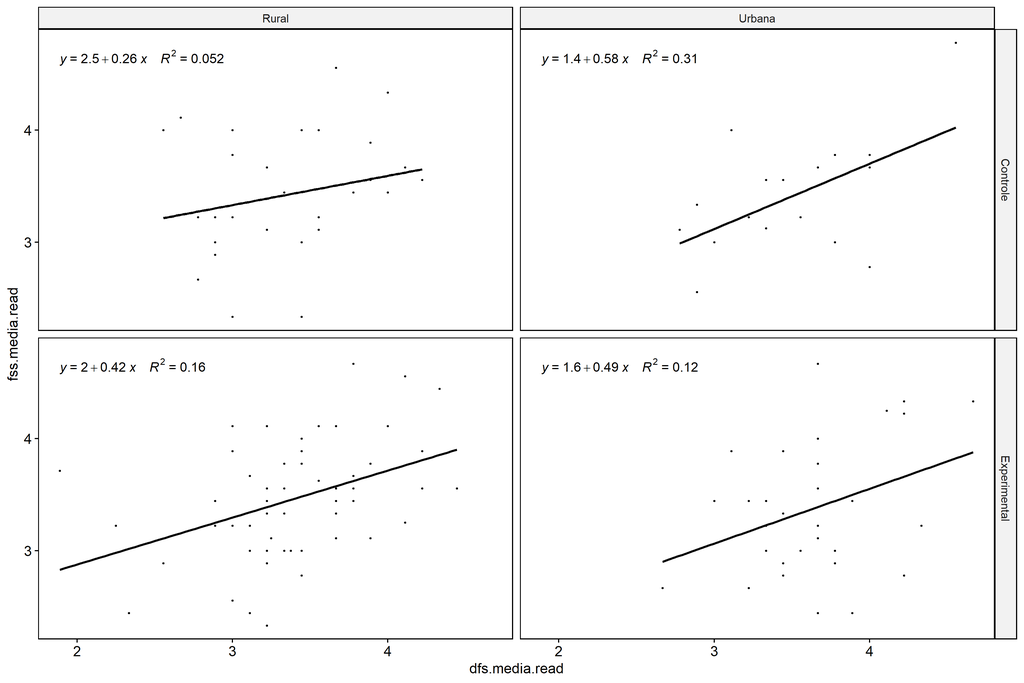

```r
ggscatter(wdat, x = "dfs.media.read", y = "fss.media.read", size = 0.5,
          facet.by = c("grupo","Zona"), add = "reg.line")+
  stat_regline_equation(
    aes(label =  paste(..eq.label.., ..rr.label.., sep = "~~~~"))
  )
```

### Checking normality and homogeneity

```r
res <- augment(lm(fss.media.read ~ dfs.media.read + grupo*Zona, data = wdat))
```

```r
shapiro_test(res$.resid)
```

```
## # A tibble: 1 × 3
##   variable   statistic p.value
##   <chr>          <dbl>   <dbl>
## 1 res$.resid     0.990   0.423
```

```r
levene_test(res, .resid ~ grupo*Zona)
```

```
## # A tibble: 1 × 4
##     df1   df2 statistic     p
##   <int> <int>     <dbl> <dbl>
## 1     3   133      1.36 0.257
```

# ANCOVA and Pairwise for two factors **grupo:Cor.Raca**

## Without remove non-normal data

```r
pdat = remove_group_data(dat[!is.na(dat[["grupo"]]) & !is.na(dat[["Cor.Raca"]]),], "fss.media.read", c("grupo","Cor.Raca"))

pdat.long <- rbind(pdat[,c("id","grupo","Cor.Raca")], pdat[,c("id","grupo","Cor.Raca")])
pdat.long[["time"]] <- c(rep("pre", nrow(pdat)), rep("pos", nrow(pdat)))
pdat.long[["time"]] <- factor(pdat.long[["time"]], c("pre","pos"))
pdat.long[["flow.read"]] <- c(pdat[["dfs.media.read"]], pdat[["fss.media.read"]])

aov = anova_test(pdat, fss.media.read ~ dfs.media.read + grupo*Cor.Raca)
laov[["grupo:Cor.Raca"]] <- get_anova_table(aov)
```

```r
pwcs <- list()
pwcs[["Cor.Raca"]] <- emmeans_test(
  group_by(pdat, grupo), fss.media.read ~ Cor.Raca,
  covariate = dfs.media.read, p.adjust.method = "bonferroni")
pwcs[["grupo"]] <- emmeans_test(
  group_by(pdat, Cor.Raca), fss.media.read ~ grupo,
  covariate = dfs.media.read, p.adjust.method = "bonferroni")

pwc <- plyr::rbind.fill(pwcs[["grupo"]], pwcs[["Cor.Raca"]])
pwc <- pwc[,c("grupo","Cor.Raca", colnames(pwc)[!colnames(pwc) %in% c("grupo","Cor.Raca")])]
```

```r
pwc.long <- emmeans_test(dplyr::group_by_at(pdat.long, c("grupo","Cor.Raca")),
                         flow.read ~ time,
                         p.adjust.method = "bonferroni")
lpwc[["grupo:Cor.Raca"]] <- plyr::rbind.fill(pwc, pwc.long)
```

```r
ds <- get.descriptives(pdat, "fss.media.read", c("grupo","Cor.Raca"), covar = "dfs.media.read")
ds <- merge(ds[ds$variable != "dfs.media.read",],
            ds[ds$variable == "dfs.media.read", !colnames(ds) %in% c("variable")],
            by = c("grupo","Cor.Raca"), all.x = T, suffixes = c("", ".dfs.media.read"))
ds <- merge(get_emmeans(pwcs[["grupo"]]), ds, by = c("grupo","Cor.Raca"), suffixes = c(".emms", ""))
ds <- ds[,c("grupo","Cor.Raca","n","mean.dfs.media.read","se.dfs.media.read","mean","se","emmean","se.emms")]

colnames(ds) <- c("grupo","Cor.Raca", "N", paste0(c("M","SE")," (pre)"),
                  paste0(c("M","SE"), " (unadj)"), paste0(c("M", "SE"), " (adj)"))

lemms[["grupo:Cor.Raca"]] <- ds
```